# Práctica de Aprendizaje Computacional

Juan Diego Gallego Nicolás, Yago Ibarrola Lapeña, Ginés Carrillo Ibáñez

2025-06-04

# 1 Introducción

Este documento es la memoria de nuestra práctica para la asignatura *Aprendizaje Computacional* de la Mención en Computación del Grado de Informática de la Universidad de Murcia.

El proyecto consiste en el estudio de diferentes modelos de aprendizaje automático. Para ello, se ha utilizado la base de datos [Credit Approval](https://archive.ics.uci.edu/dataset/27/credit+approval) de [UC Irvine Machine Learning Repository](https://archive.ics.uci.edu/), que contiene información sobre la concesión o denegación de créditos bancarios.

En primer lugar, se ha llevado a cabo un análisis exploratorio de la base de datos. Hemos identificado atributos numéricos y categóricos y hemos renombrado las columnas según la información que hemos encontrado en un repositorio de [Kaggle](https://www.kaggle.com/code/dilipkumarb/credit-card-approval-classification-model). Hemos proseguido con una serie de análisis monovariable y multivariable discriminando entre créditos concedidos y denegados. Esto nos ha permitido hacernos una idea de la relación entre los diferentes atributos. Para cerrar esta sección, hemos probado un Análisis de Componentes Principales (PCA) para tener una referencia sencilla con la que comparar los modelos de aprendizaje.

# 2 Carga y preparación de datos

Comenzamos instalando las librerías de R necesarias para la elaboración de la práctica: - caret (Classification And REgresion Training): paquete para entrenar modelos de machine learning en R. Facilita, entre otros, el preprocesado de datos, la división de conjuntos de train/test, el ajuste de hiperparámetros… - tidyverse: colección de paquetes para ciencia de datos. Permite manipulación de datos, lectura de archivos y creación de gráficos. - ggplot2: creación de gráficos. - gridExtra: permite combinar varios ggplot en una sola figura.

También cargamos el [dataset](https://archive.ics.uci.edu/static/public/27/credit+approval.zip) y vemos su contenido. Observamos una tabla de 690 filas y 16 columnas. Las columnas `V1`, `V4`, `V5`, `V6`, `V7`, `V9`, `V10`, `V12`, `V13` y `V16` contienen caracteres, lo que nos indica que son categóricas. El resto de columnas son numéricas.

```r
if (!requireNamespace("caret", quietly = TRUE)) {
    install.packages("caret")
}

if (!requireNamespace("tidyverse", quietly = TRUE)) {
    install.packages("tidyverse")
}
if (!requireNamespace("ggplot2", quietly = TRUE)) {
    install.packages("ggplot2")
}
if (!requireNamespace("gridExtra", quietly = TRUE)) {
    install.packages("gridExtra")
}
if (!requireNamespace("GGally", quietly = TRUE)) {
    install.packages("GGally")
}


library(caret)
library(tidyverse)
library(ggplot2)
library(gridExtra)
library(GGally)

# Cargar dataset
url <- "https://archive.ics.uci.edu/static/public/27/credit+approval.zip"

# Download and unzip the dataset
temp <- tempfile()
download.file(url, temp)
unzip(temp, exdir = "./credit")
unlink(temp)  # Remove temporary file

credit <- read.table("./credit/crx.data", sep = ",", na.strings ="?")

summary(credit)
```

```
##       V1                  V2              V3              V4
##  Length:690         Min.   :13.75   Min.   : 0.000   Length:690
##  Class :character   1st Qu.:22.60   1st Qu.: 1.000   Class :character
##  Mode  :character   Median :28.46   Median : 2.750   Mode  :character
##                     Mean   :31.57   Mean   : 4.759
##                     3rd Qu.:38.23   3rd Qu.: 7.207
##                     Max.   :80.25   Max.   :28.000
##                     NA's   :12
##       V5                 V6                 V7                  V8
##  Length:690         Length:690         Length:690         Min.   : 0.000
##  Class :character   Class :character   Class :character   1st Qu.: 0.165
##  Mode  :character   Mode  :character   Mode  :character   Median : 1.000
##                                                           Mean   : 2.223
##                                                           3rd Qu.: 2.625
##                                                           Max.   :28.500
##
##       V9                V10                 V11           V12
##  Length:690         Length:690         Min.   : 0.0   Length:690
##  Class :character   Class :character   1st Qu.: 0.0   Class :character
##  Mode  :character   Mode  :character   Median : 0.0   Mode  :character
##                                        Mean   : 2.4
##                                        3rd Qu.: 3.0
##                                        Max.   :67.0
##
##      V13                 V14            V15               V16
##  Length:690         Min.   :   0   Min.   :     0.0   Length:690
##  Class :character   1st Qu.:  75   1st Qu.:     0.0   Class :character
##  Mode  :character   Median : 160   Median :     5.0   Mode  :character
##                     Mean   : 184   Mean   :  1017.4
##                     3rd Qu.: 276   3rd Qu.:   395.5
##                     Max.   :2000   Max.   :100000.0
##                     NA's   :13
```

# 3 Análisis Exploratorio de Datos (EDA)

La primera labor que debemos llevar a cabo al empezar a trabajar con un dataset desconocido es entender la información que este contiene. En esta fase, conocida como Análisis Exploratorio de Datos, llevaremos a cabo las siguientes tareas: - **Etiquetado de los atributos**: en vista de la ausencia de etiquetas interpretables para los atributos del dataset, en esta primera etapa hemos buscado entender el significado de cada uno de ellos y renombrarlos de manera más intuitiva. - **Análisis monovariable**: a continuación, hemos analizado las distribuciones seguidas por cada uno de los atributos, estudiando también sus valores máximos, mínimos, medias y cuartiles. - **Analísis multivariable**: finalmente, hemos realizado un estudio de cómo distintos atributos se relacionan entre sí.

## 3.1 Etiquetado de los atributos

En un primer momento, intentamos averiguar los significados de los campos de forma manual. Conseguimos deducir que el atributo ’`V2` representa la edad del solicitante, percatándonos de que los decimales correspondían con múltiplos de 1/12 (por ejemplo, el valor 34.083 se corresponde con la edad de 34 años y 1 mes).

Otro campo que pudimos deducir fue el de Ingresos (`V15`), basándonos en la distribución que tomaban sus valores (y que veremos más adelante).

Finalmente, decidimos investigar en foros online para buscar el significado del resto de atributos. Ahí es cuando encontramos el siguiente proyecto de [Kaggle](https://www.kaggle.com/code/dilipkumarb/credit-card-approval-classification-model).

Con esta información, renombramos las columnas:

```r
colnames(credit)[colnames(credit) == "V1"] ="Sexo"
colnames(credit)[colnames(credit) == "V2"] ="Edad"
colnames(credit)[colnames(credit) == "V3"] ="Deuda"
colnames(credit)[colnames(credit) == "V4"] ="Estado_civil"
colnames(credit)[colnames(credit) == "V5"] ="Es_cliente"
colnames(credit)[colnames(credit) == "V6"] ="Nivel_educativo"
colnames(credit)[colnames(credit) == "V7"] ="Etnia"
colnames(credit)[colnames(credit) == "V8"] ="Anos_cotizados"
colnames(credit)[colnames(credit) == "V9"] ="Impago_previo"
colnames(credit)[colnames(credit) == "V10"] ="Trabaja"
colnames(credit)[colnames(credit) == "V11"] ="Calificacion_crediticia"
colnames(credit)[colnames(credit) == "V12"] ="Licencia_de_conducir"
colnames(credit)[colnames(credit) == "V13"] ="Ciudadano"
colnames(credit)[colnames(credit) == "V14"] ="Codigo_postal"
colnames(credit)[colnames(credit) == "V15"] ="Ingresos"
colnames(credit)[colnames(credit) == "V16"] ="Aprobado"
```

También distinguimos entre campos categóricos y numéricos. Los datos categóricos se deben tratar como el tipo factor. Algunos campos numéricos conviene visualizarlos en escala logarítmica.

```r
campos = 1:15
campos_numericos = c(2, 3, 8, 11, 14, 15)
campos_log = c(8, 11, 15)
campos_no_log = setdiff(campos_numericos, campos_log)
campos_categoricos = setdiff(campos, campos_numericos)
#campos_categoricos = c("Sexo", "Estado_civil", "Es_cliente", "Nivel_educativo", "Etnia", "Impago_previo", "Trabaja", "Licenc", "Ciudadano", "Aprobado") #nolint
credit[campos_categoricos] <- lapply(credit[campos_categoricos], FUN = as.factor)
lapply(credit[campos_categoricos], FUN = levels)
```

```
## $Sexo
## [1] "a" "b"
##
## $Estado_civil
## [1] "l" "u" "y"
##
## $Es_cliente
## [1] "g"  "gg" "p"
##
## $Nivel_educativo
##  [1] "aa" "c"  "cc" "d"  "e"  "ff" "i"  "j"  "k"  "m"  "q"  "r"  "w"  "x"
##
## $Etnia
## [1] "bb" "dd" "ff" "h"  "j"  "n"  "o"  "v"  "z"
##
## $Impago_previo
## [1] "f" "t"
##
## $Trabaja
## [1] "f" "t"
##
## $Licencia_de_conducir
## [1] "f" "t"
##
## $Ciudadano
## [1] "g" "p" "s"
```

Añadimos los valores que faltan que pueden tomar algunas de las variables, en este caso a la variable estado civil le falta el valor “t”.

```r
levels(credit$Estado_civil) <- c(levels(credit$Estado_civil), "t")
```

## 3.2 Análisis univariable

Para llevar a cabo el análisis monovariable, distinguiremos entre los atributos numéricos y categóricos, pues la forma de tratarlos es completamente distinta.

### 3.2.1 Atributos numéricos

Para los atributos numéricos, es interesante como punto de partida mostrar su valor mínimo, máximo, los cuartiles, la media y la mediana.

```r
# Tabla con los atributos
atributosNum <- credit[,c(2,3,8,11,14,15)]

summary(atributosNum)
```

```
##       Edad           Deuda        Anos_cotizados   Calificacion_crediticia
##  Min.   :13.75   Min.   : 0.000   Min.   : 0.000   Min.   : 0.0
##  1st Qu.:22.60   1st Qu.: 1.000   1st Qu.: 0.165   1st Qu.: 0.0
##  Median :28.46   Median : 2.750   Median : 1.000   Median : 0.0
##  Mean   :31.57   Mean   : 4.759   Mean   : 2.223   Mean   : 2.4
##  3rd Qu.:38.23   3rd Qu.: 7.207   3rd Qu.: 2.625   3rd Qu.: 3.0
##  Max.   :80.25   Max.   :28.000   Max.   :28.500   Max.   :67.0
##  NA's   :12
##  Codigo_postal     Ingresos
##  Min.   :   0   Min.   :     0.0
##  1st Qu.:  75   1st Qu.:     0.0
##  Median : 160   Median :     5.0
##  Mean   : 184   Mean   :  1017.4
##  3rd Qu.: 276   3rd Qu.:   395.5
##  Max.   :2000   Max.   :100000.0
##  NA's   :13
```

Vamos a mostrar ahora gráficamente estos atributos, junto con un histograma que nos sirve como primera toma de contacto con la distribución que siguen dichos atributos.

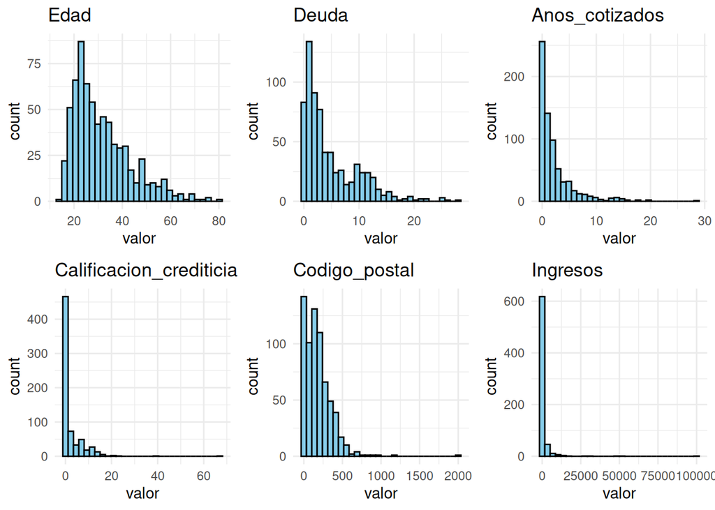

```r
# Crear una lista para guardar los histogramas
plots <- list()

for (i in campos_numericos) {
  var <- names(credit)[i]
  var_data <- na.omit(credit[[var]])
# Saltar si la columna no tiene datos suficientes
  if (length(var_data) < 2) next
  df_temp <- data.frame(valor = var_data)

  p <- ggplot(df_temp, aes(x = valor)) +
    geom_histogram(bins = 30, fill = "skyblue", color = "black") +
    ggtitle(var) +
    theme_minimal()

  plots[[var]] <- p
}

grid.arrange(grobs = plots, ncol = 3)
```

Claramente hay variables como la de Ingresos o Calificacion_crediticia que pierden mucha información al representarse con el histograma. Utilizando escala logarítmica se puede distinguir mejor la población:

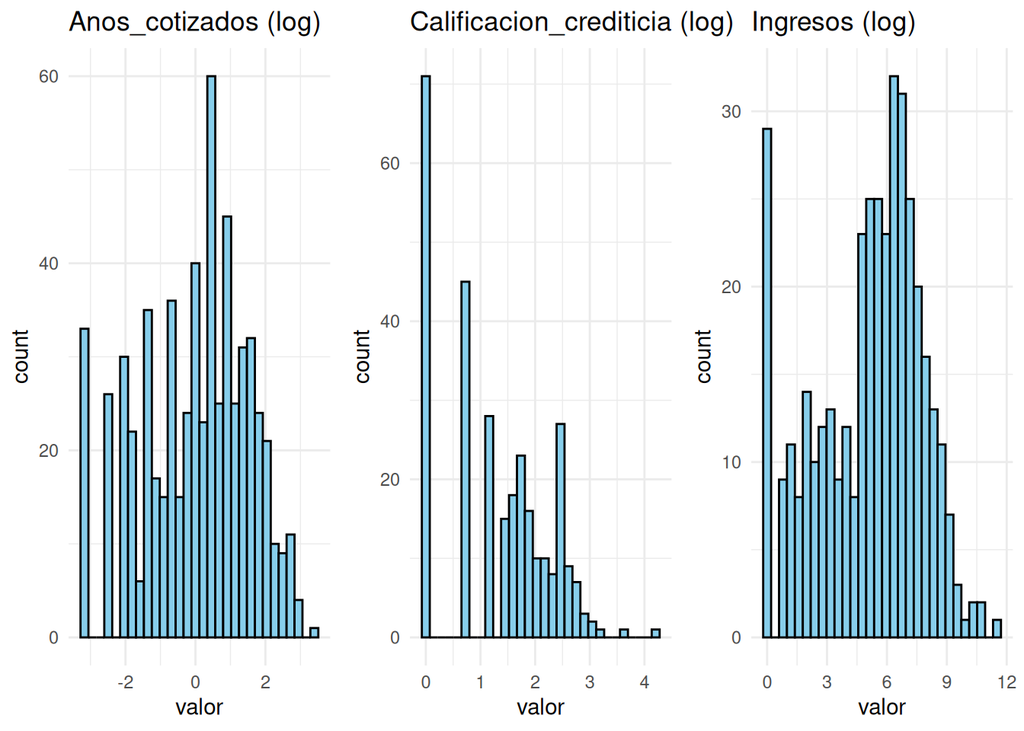

```r
# Crear una lista para guardar los histogramas
plots <- list()

for (i in campos_log) {
    var <- names(credit)[i]
    var_data <- na.omit(credit[[var]])
    # Saltar si la columna no tiene datos suficientes o si hay valores no positivos
    var_data_log <- var_data[var_data > 0]
    if (length(var_data_log) < 2) next
    df_temp <- data.frame(valor = log(var_data_log))

    p <- ggplot(df_temp, aes(x = valor)) +
        geom_histogram(bins = 30, fill = "skyblue", color = "black") +
        ggtitle(paste0(var, " (log)")) +
        theme_minimal()

    plots[[var]] <- p
}

grid.arrange(grobs = plots, ncol = 3)
```

En el caso del atributo Calificacion_crediticia, vemos que hay una gran cantidad de muestras que tienen el valor 0 en este campo. Esto se puede deber a que el banco no conoce este dato o bien que la mayor parte de la gente acaba de abrirse la cuenta del banco y de momento no tiene una calificación crediticia positiva.

También vemos una cantidad elevado de personas con cero ingresos. Igual que en el caso anterior, seguramente se deba a desconocimiento del valor, pues no es frecuente que una cantidad tan elevada de la población tenga 0 ingresos.

Ahora queremos comprobar si alguno de los atributos sigue una distribución normal. Para ello utilizamos qqplot para comparar la función de distribución de nuestros atributos con la de la distribución normal:

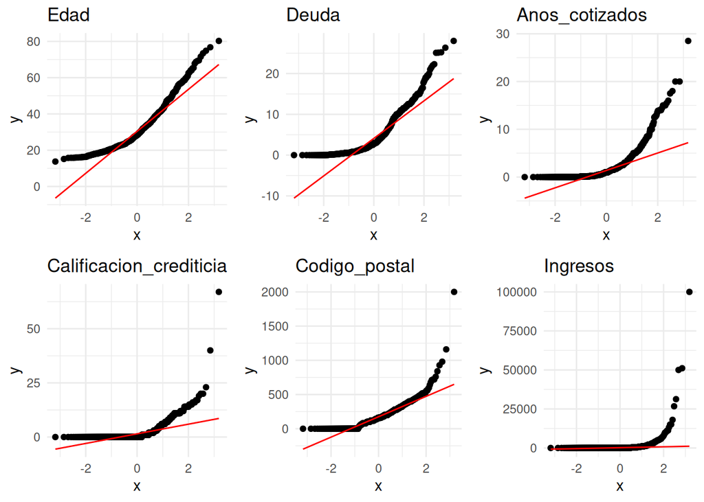

```r
library(ggplot2)
library(gridExtra)

# Lista para guardar los Q-Q plots
qqplots <- list()

for (i in campos_numericos) {
  var <- names(credit)[i]
  var_data <- na.omit(credit[[i]])

  # Saltar si hay pocos datos
  if (length(var_data) < 3) next

  df_temp <- data.frame(valor = var_data)

  # Q-Q plot usando stat_qq
  p <- ggplot(df_temp, aes(sample = valor)) +
    stat_qq() +
    stat_qq_line(color = "red") +
    ggtitle(paste(var)) +
    theme_minimal()

  qqplots[[var]] <- p
}

# Mostrar todos los Q-Q plots en una cuadrícula
grid.arrange(grobs = qqplots, ncol = 3)
```

Llegamos a la conclusión de que ninguno de los atributos sigue una distribución normal.

La que más se acerca sería la del código postal. Esto podría tener cierto sentido debido a que la mayor parte de los solicitantes vivirán cerca del banco en cuestión. Teniendo en cuenta que lugares cercanos suelen tener códigos postales próximos, tiene mucho sentido que cuanto más nos alejamos del banco (y por consecuente de su código postal), menos solicitantes habrá.

Siguiendo el razonamiento anterior, parece convenienente comprobar si las variables que anteriormente visualizamos en escala logarítmica, siguen una distribución lognormal. Para ello simplemente repetimos el procedimiento anterior con las variables tras aplicarle el logaritmo:

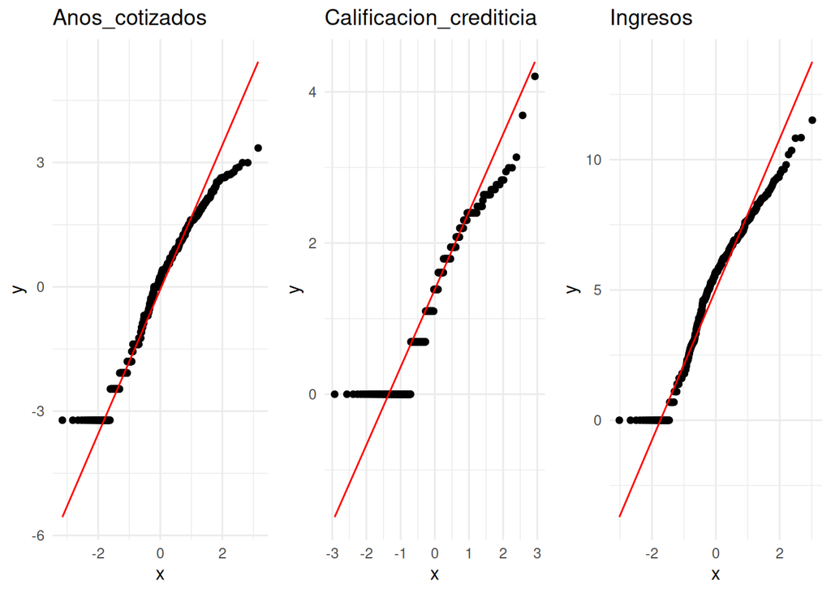

```r
library(ggplot2)
library(gridExtra)

# Lista para guardar los Q-Q plots
qqplots <- list()

for (i in campos_log) {
  var <- names(credit)[i]
  var_data <- na.omit(credit[[var]])
# Saltar si la columna no tiene datos suficientes o si hay valores no positivos
  var_data_log <- var_data[var_data > 0]
  if (length(var_data_log) < 2) next
  df_temp <- data.frame(valor = log(var_data_log))


  # Q-Q plot usando stat_qq
  p <- ggplot(df_temp, aes(sample = valor)) +
    stat_qq() +
    stat_qq_line(color = "red") +
    ggtitle(paste(var)) +
    theme_minimal()

  qqplots[[var]] <- p
}

# Mostrar todos los Q-Q plots en una cuadrícula
grid.arrange(grobs = qqplots, ncol = 3)
```

Vemos que estas tres variables se ajustan mucho mejor a una distribución lognormal que a una normal.

#### 3.2.1.1 Análisis univariable del predictor `Ingresos`

```r
library(ggplot2)

# Eliminamos NA por seguridad
ingresos <- na.omit(credit$Ingresos)

# Estadísticos básicos
summary(ingresos)
```

```
##     Min.  1st Qu.   Median     Mean  3rd Qu.     Max.
##      0.0      0.0      5.0   1017.4    395.5 100000.0
```

```r
sd(ingresos)
```

```
## [1] 5210.103
```

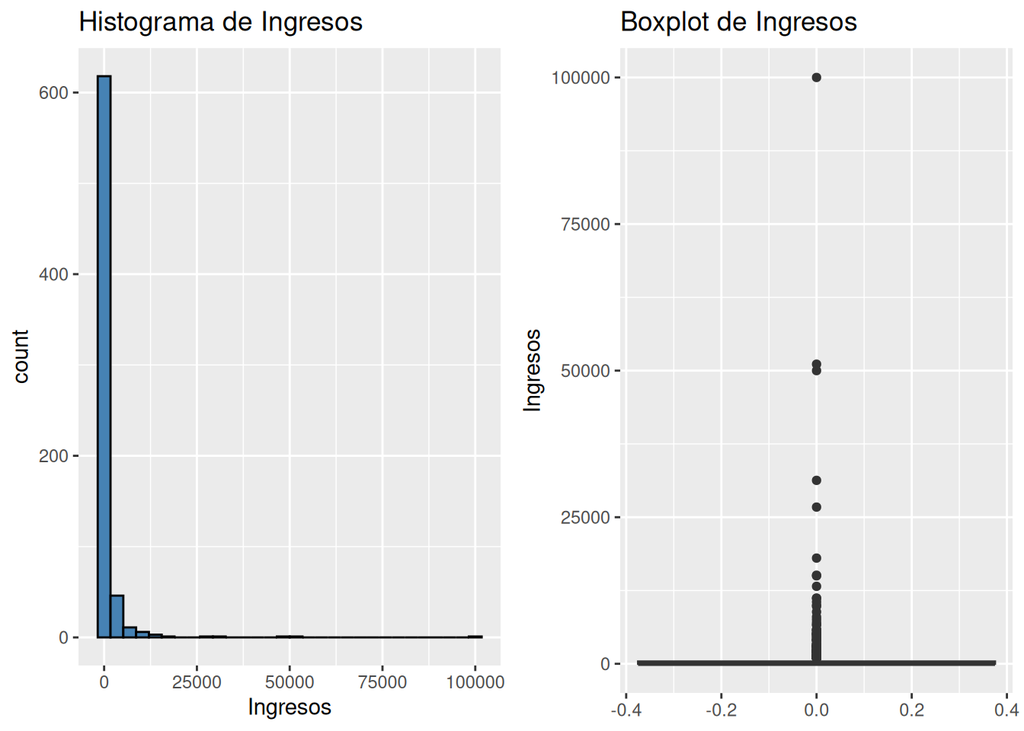

```r
# Histograma y Boxplot
p1 <- ggplot(data.frame(Ingresos = ingresos), aes(x = Ingresos)) +
  geom_histogram(bins = 30, fill = "steelblue", color = "black") +
  labs(title = "Histograma de Ingresos")

p2 <- ggplot(data.frame(Ingresos = ingresos), aes(y = Ingresos)) +
  geom_boxplot(fill = "orange") +
  labs(title = "Boxplot de Ingresos")

gridExtra::grid.arrange(p1, p2, ncol = 2)
```

La variable Ingresos presenta una distribución altamente asimétrica, con una gran concentración de valores bajos y una cola larga hacia la derecha. Esto se confirma con el histograma y el boxplot, donde se observan muchos valores en cero y varios outliers.

```r
# Test de Shapiro-Wilk para normalidad
shapiro.test(ingresos)
```

```
##
##  Shapiro-Wilk normality test
##
## data:  ingresos
## W = 0.16985, p-value < 2.2e-16
```

```r
# Log-transformación (se suman +1 para evitar log(0))
log_ingresos <- log(ingresos + 1)

# Test de Shapiro-Wilk sobre log(Ingresos)
shapiro.test(log_ingresos)
```

```
##
##  Shapiro-Wilk normality test
##
## data:  log_ingresos
## W = 0.82425, p-value < 2.2e-16
```

La prueba de Shapiro-Wilk sobre los ingresos originales da como resultado un p-valor muy bajo, indicando que no siguen una distribución normal. Tras aplicar una transformación logarítmica (log(Ingresos + 1)), la distribución mejora notablemente en forma, aunque el p-valor obtenido sigue siendo muy bajo, lo que nos confirma que tampoco sigue una distribución lognormal. El Q-Q plot también muestra una mejor alineación con la recta teórica tras la transformación.

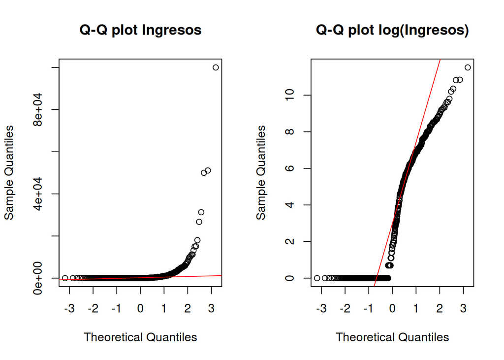

```r
# Q-Q plot para Ingresos y log(Ingresos)
par(mfrow = c(1,2))

qqnorm(ingresos, main = "Q-Q plot Ingresos")
qqline(ingresos, col = "red")

qqnorm(log_ingresos, main = "Q-Q plot log(Ingresos)")
qqline(log_ingresos, col = "red")
```

Nuestra siguiente intención es comprobar si este predictor sirve como una buena primera aproximación para distinguir entre personas a las que se le concedió el crédito y a las que no.

Para ello dividimos la población total entre aprobados y no aprobados y representamos con un boxplot cada una:

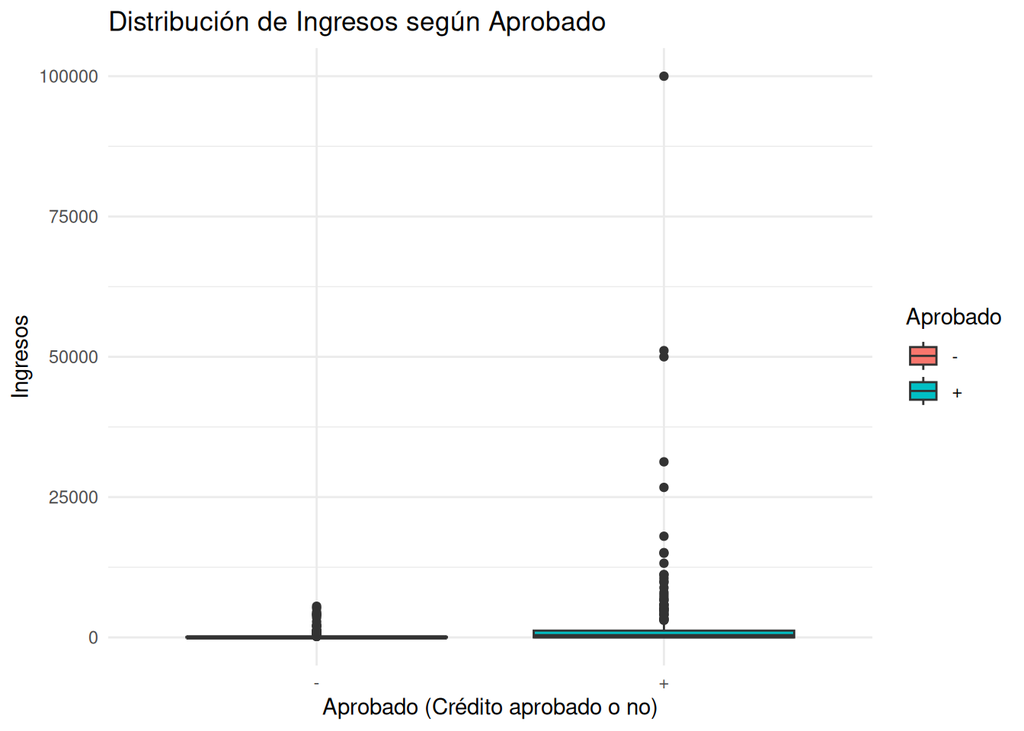

```r
# Eliminar NA
df_ingresos <- credit[!is.na(credit$Ingresos) & !is.na(credit$Aprobado), ]

# Boxplot de Ingresos por Clase
ggplot(df_ingresos, aes(x = Aprobado, y = Ingresos, fill = Aprobado)) +
  geom_boxplot() +
  labs(title = "Distribución de Ingresos según Aprobado",
       x = "Aprobado (Crédito aprobado o no)",
       y = "Ingresos") +
  theme_minimal()
```

Para visualizar mejor el boxplot, transformamos los datos a escala logaritmica:

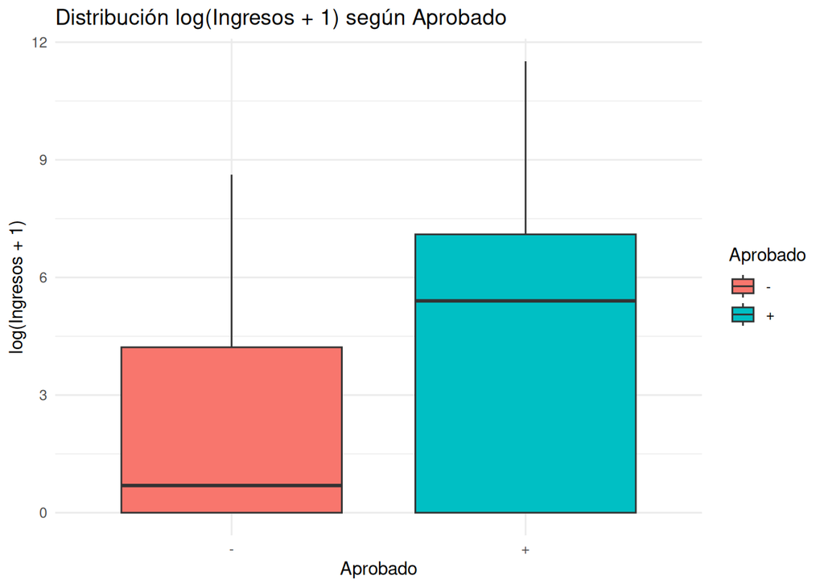

```r
  # También puedes ver la versión log-transformada (opcional)
df_ingresos$log_ingresos <- log(df_ingresos$Ingresos + 1)

ggplot(df_ingresos, aes(x = Aprobado, y = log_ingresos, fill = Aprobado)) +
  geom_boxplot() +
  labs(title = "Distribución log(Ingresos + 1) según Aprobado",
       x = "Aprobado",
       y = "log(Ingresos + 1)") +
  theme_minimal()
```

En este diagrama sí que se aprecia mucho mejor que a la gente que se le concedió el crédito tiene de media muchos más ingresos, confirmando así nuestra teoría.

Podemos mostrar también las funciones de densidad para cada una de las clases, en escala logarítmica para una mejor visualización:

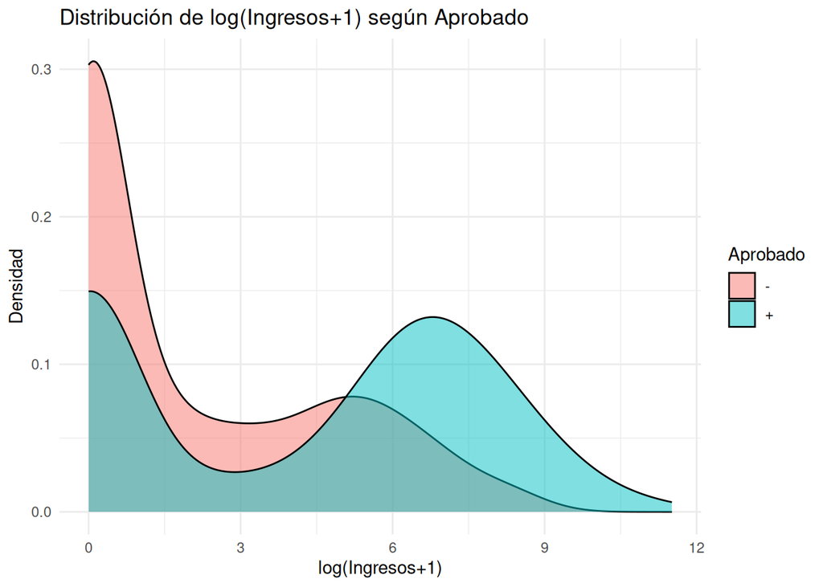

```r
ggplot(df_ingresos, aes(x = log_ingresos, fill = Aprobado)) +
  geom_density(alpha = 0.5) +
  labs(title = "Distribución de log(Ingresos+1) según Aprobado",
       x = "log(Ingresos+1)",
       y = "Densidad") +
  theme_minimal()
```